# Robot motion planning

Ilya Semenov

14 June 2017

# Plot and Navigate a Virtual Maze

## Capstone project report for Udacity machine learning engineer nanodegree

### Project description

The project takes inspiration from Micromouse competitions, wherein a robot mouse is tasked with plotting a path from a corner of the maze to its center. The robot mouse may make two runs in a given maze. In the first run, the robot mouse tries to map out the maze to not only find the center, but also figure out the best paths to the center. During the second run, the robot mouse attempts to reach the center in the fastest time possible, using what it has previously learned.

Maze solving is a well known academic problem in the robotics field, some approaches described, for example, in following papers:

- [Maze Solving Algorithms for Micro Mouse](https://www.researchgate.net/publication/224363078_Maze_Solving_Algorithms_for_Micro_Mouse)
- [An Efficient Algorithm for Robot Maze-Solving](https://www.researchgate.net/publication/224179519_An_Efficient_Algorithm_for_Robot_Maze-Solving)
- [A New Shortest First Path Finding Algorithm for a Maze Solving Robot](http://www.ijcst.com/vol63/2/31-amanpreet-singh.pdf)

### Project requirements

#### Requirements

- Python 2.7.x
- Numpy library

#### Deliverables

Project submission includes:

- PDF report of algorithms used and approaches taken to problem (this file)
- Python scripts for testing virtual robot ( **robot.py** and **graph.py**)
- README text file entitled “Plot and navigate a virtual maze” describing the submitted files

The submission is packed in a single .zip archive.

### I. Problem statement

#### Maze definition

The maze exists on an N x N grid of squares, N is even. The minimum value of N is twelve, the maximum sixteen. Along the outside perimeter of the grid, and on the edges connecting some of the internal squares, are walls that block all movement. The robot will start in the square in the bottom- left corner of the grid, facing upwards. The starting square will always have a wall on its right side (in addition to the outside walls on the left and bottom) and an opening on its top side. In the center of the grid is the goal room consisting of a 2 x 2 square; the robot must make it here from its starting square in order to register a successful run of the maze.

#### Robot definition

The robot can be considered to rest in the center of the square it is currently located in, and points in one of the cardinal directions of the maze. The robot has three obstacle sensors, mounted on the front of the robot, its right side, and its left side. Obstacle sensors detect the number of open squares in the direction of the sensor; for example, in its starting position, the robot’s left and right sensors will state that there are no open squares in those directions and at least one square towards its front. On each time step of the simulation, the robot may choose to rotate clockwise or counterclockwise ninety degrees, then move forwards or backwards a distance of up to three units. It is assumed that the robot’s turning and movement is perfect. If the robot tries to move into a wall, the robot stays where it is. After movement, one time step has passed, and the sensors return readings for the open squares in the robot’s new location and/or orientation to start the next time unit.

*Complement to Udacity robot definition*

- sensor range in all directions is three cells for all three sensors
- robot recieves sensor data only when it reaches a final cell of movement sequence (for example, if robot moves two cells forward it recieves sensor data from the second cell only)

*Note*

- according to robot definition from above diagonal moves are forbidden

#### Scoring

On each maze, the robot must complete two runs. In the first run, the robot is allowed to freely roam the maze to build a map of the maze. It must enter the goal room at some point during its exploration, but is free to continue exploring the maze after finding the goal. After entering the goal room, the robot may choose to end its exploration at any time. The robot is then moved back to the starting position and orientation for its second run. The robot’s score for the maze is equal to the number of time steps required to execute the second run, plus one thirtieth the number of time steps required to execute the first run. A maximum of one thousand time steps are allotted to complete both runs for a single maze.

#### Robot’s goal

Using the maze configuration data collected during explorational phase move from start position to the center of the maze as quickly as possible during the final phase.

##### Maze configuration

Mazes are provided to the system via text file. On the first line of the text file is a number describing the number of squares on each dimension of the maze n. On the following n lines, there will be n comma-delimited numbers describing which edges of the square are open to movement. Each number represents a four-bit number that has a bit value of 0 if an edge is closed (walled) and 1 if an edge is open (no wall); the 1s register corresponds with the upwards-facing side, the 2s register the right side, the 4s register the bottom side, and the 8s register the left side. For example, the number 10 means that a square is open on the left and right, with walls on top and bottom (0*1 + 1*2 + 0*4 + 1*8 = 10). Note that, due to array indexing, the first data row in the text file corresponds with the leftmost column in the maze, its first element being the starting square (bottom-left) corner of the maze.

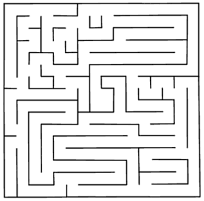

Micromouse maze example

##### Robot interface

At the start of a time step the robot will receive sensor readings as a list of three numbers indicating the number of open squares in front of the left, center, and right sensors (in that order) to its **next_move()** function. The **next_move()** function must then return two values indicating the robot’s rotation and movement on that timestep. Rotation is expected to be an integer taking one of three values: -90, 90, or 0, indicating a counterclockwise, clockwise, or no rotation, respectively. Movement follows rotation, and is expected to be an integer in the range [-3, 3] inclusive. The robot will attempt to move that many squares forward (positive) or backwards (negative), stopping movement if it encounters a wall.

##### Starter code

Robot and maze specifications along with other support code provided by Udacity will be downloaded from the following [link](https://www.google.com/url?q=https://drive.google.com/open?id%3D0B9Yf01UaIbUgQ2tjRHhKZGlHSzQ&sa=D&ust=1494016198842000&usg=AFQjCNEX_ZWFnq3IIwSmmUkXfYdaJtn2ag).

#### Data preprocessing

No data preprocessing required in a given project pipeline.

### II. Analysis

#### General review

According to task description there are only three available maze sizes: 12x12, 14x14 and 16x16 cells. Regardless of the size each given maze has 4 cells goal room without inner walls in the center of the maze and the starting point is always located at the down left corner of the maze. Robot movement algorithm must be invariant to maze size.

It is assumed that the robot movement and rotation are perfect. Any valid robot movement may or may not include rotation 90 degrees clockwise or anticlockwise and than up to three cells movement phase forwards or backwards. Any valid robot movement with or without rotation takes exactly one time-step.

Robot interface implementation provided by Udacity prevents incorrect moves, that are, for example, moves that cause the robot to hit the wall. Since the robot interface does not provide coordinates inside the maze (on each step we have sensors info only) the algorithm should correctly maintain robot’s position inside the maze and avoid unacceptable moves propositions since it would cause synchronization loss between actual robot position inside the maze and robot position that used by the algorithm internally. Synchronization loss between real and internal positions would almost definitely cause the robot to fail in final phase while trying to reach target cells.

Let consider the simplest 12x12 maze given by Udacity (Figure 2). Optimal path outlined with green color and takes 17 time-steps. To be more precise the path for this maze is as follows (in each tuple first letter denotes rotation and second number denotes No of cells to move):

(F,2), (R,1), (R,2), (L,3), (L,2), (R,2), (R,1), (L,1), (R,1), (L,3), (F,1), (L,3), (L,3), (R,2), (L,1), (R,1), (L,1).

“F” stands for forward, “L” stands for left turn and “R” stands for right turn accordingly.

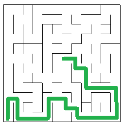

Optimal solution for Maze 1 from test mazes set provided by Udacity

Observations from Figure 2:

1. One may immediately note that most moves in an optimal path assume left or right turns.
2. Path to the center is definitely not straightforward and includes portions where robot moves in an opposite direction from the maze center.
3. During each step robot only has input from three sensors denoting the distance to the nearest wall in this direction, thus at every step, maybe except of the final one, it’s hard to provide the robot with clues about what rotation and moving distance are preferable in terms of optimal path search.
4. Even when some path from start to finish is found, we cannot be sure that this path is optimal for the given maze while we have maze cells unvisited by the robot thus making the maze routes space complete.

In order to explore maze route space we can take two approaches: deterministic and random.

Deterministic approach assumes consistent visiting of every available cell. One possible way is as follows:

- we limit robot movement by exactly one cell
- for each cell we memorize its one cell away neighbors to the left, forward and right and put every reachable neighbor to ‘unvisited’ stack
- move to the left cell, if possible, otherwise move forward, otherwise move right, otherwise move towards first unvisited cell from the stack
- repeat until the ‘unvisited’ stack is not empty

This algorithm guarantees visiting every maze cell that is reachable from the start, but is slow in terms of time-steps required.

Random exploration assumes more or less random roaming through the maze, maybe with some optimization heuristics, with hope that the robot will be ‘lucky’ in discovering short path to the center without visiting every cell.

Those considerations suggest random exploration during first phase of the competition in order for the robot to learn given maze configuration trying to find out as many available routes to the center as possible. At the same time we have limited time steps budget and penalty for every excess move during exploration phase so the algorithm should take into account exploration-exploitation dilemma while deciding whether to continue exploration or to stop on finding some path that may not be optimal for given configuration.

#### Proposed solution

My general approach is to build a maze connectivity graph during an exploration phase and on each step of exploration find an optimal solution for travelling from start to goal cells. Since each cell has a unique address that could be represented by an integer (for example from 0 to 255 in 16x16 maze case) we can define graph vertices as cells and define graph edges as routes we can travel from given cell to its neighbor in exactly one time-step.

Initially the connectivity graph has no edges. Each exploration step adds edges to the graph according to the data obtained from robot sensors.

For optimal solution search we can use [Dijkstra’s algorithm](https://en.wikipedia.org/wiki/Dijkstra%27s_algorithm) since it has complexity upper bound [O(V-squared)](https://en.wikipedia.org/wiki/Dijkstra%27s_algorithm#Running_time), where V is the number of graph vertices. According to problem statement maximum number of vertices is limited to 256 (in case of 16*16 maze grid), so performing Dijkstra optimal path search on each step of exploration phase looks as feasible task in terms of computational efficiency.

In this framework final phase is just an implementation of optimal path found during exploration in case it exists and was found with boundary condition of 1000 time-steps.

Exploration phase may be defined as reinforcement learning task (similar to Train a smartcab to drive exercise in the course) with strategy described by some heuristics dedicated to minimize time required for optimal path search.

##### Exploration heuristics

- robot recieves award for moves towards the maze center
- robot is penalized for moving to a previously visited cell
- exploration stops immediately if a path with time-length of 10% or less of total number of cells is found
- robot is penalized for vertical moves towards the edges of the maze
- if a move to the center room is possible and the available cell inside the room has not been visited yet, the robot must enter the center room

Exact values for awards and penalties were to be defined during the implementation of the algorithm and described below in the document.

##### Exploration heuristics explained

By awarding center moves and penalizing moves towards the edges we are trying to prevent the robot from random roaming through the maze and prioratizing softly the movement towards the center.

Penalties for movement into previously visited cells allow to avoid loop movement and multiple dead ends visits (see Figure 3). It’s important to notice that in order to prevent loop movement effectively repeatitive cell visiting penalty should be higher than center move award.

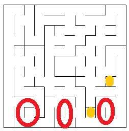

Examples of dead ends (orange) and loop movement (red)

Time-length unconditional stop is an implementation of exploration-exploitation dilemma.

Final heuristic allows to avoid unnecessary randomness in exploring the cells that are central room ‘gates’.

#### Metrics

##### Model benchmark

Model perfomance on any given maze can be scored as average number of times-steps required to find and follow a path with arbitrary number of attempts (by now 10 attempts seems as enough). We need several attempts for given maze configuration due to probabilistic nature of reinforcement learning algorithm.

This benchmark allows comparison between different models on a given maze configuration. To be more clear we’ll explain the benchmark with an example. In a table below each row represents (imaginary) total number of time-steps required for completion both explorational and final phases.

| No of test run | Model 1 | Model 2 |
| --- | --- | --- |
| 1 | 100 | 95 |
| 2 | 100 | 103 |
| 3 | 100 | 101 |
| 4 | 100 | 97 |
| 5 | 100 | 111 |
| 6 | 100 | 91 |
| 7 | 100 | 92 |
| 8 | 100 | 93 |
| 9 | 100 | 89 |
| 10 | 100 | 93 |
| —————– | ——— | ——- |
| Average time-steps required | **100** | **96.5** |

The benchmark for the Model 1 is 100, the benchmark for the Model 2 is 96.5. Since Model 2 has better benchmark than Model 1, one can claim that Model 2 coped better with a given maze configuration.

##### Evaluation metric

In order to evaluate model perfomance we can also compare the benchmark with lower and upper bounds for optimal path search on a particular maze. It could be useful to judge whether a model needs further optimization.

Lower bound defined as a shortest path length (expressed in the number of time-steps) in a given maze.

Upper bound defined as 1/30 of time-steps needed to build a complete connectivity graph by visiting all the available cells for a given maze plus the lower bound. There is some ambiguity in upper bound definition since for most maze configurations there are several ways to visit every cell. In order to avoid the ambiguity my proposal is to implement an analogue of the depth-first-search in a graph where the robot is allowed to move no farther then exactly one cell in any direction during the exploration and, where possible, prefers left turns to forward moves and forward moves to right turns subsequently.

The difference between upper and lower bounds gives a scale where benchmark described above can be expressed in % thus giving a metric to judge whether the model performance closer to ideal optimal path defined by lower bound or slow maze exploration by visiting every cell, that is upper bound. The example of that metric is as follows:

Let in an arbitrary maze optimal path length consists of 10 time-steps and slow maze exploration with visiting every available cell takes 260 time-steps. In that case:

- Lower bound equals 10.33 (10 time-steps divided by 30 for an exploration phase and 10 time-steps for a final run)
- Upper bound equals 18.67 (260/30 for exploration phase plus 10 time-steps for a final run)

(111.6 - 10)/30 + 10 = 13.37

percent_metric = ((13.37 - 10.33) / (18.67 - 10.33)) * 100% = 36.5%

The value of a metric can provide some insights on how the model performance is far from an ideal pathfinding behaviour. The ideal value of a metric is 0%.

*Note*

In case if a robot choose to follow non-optimal path according to learning heuristics the value of a metric could be more than 100%.

### III. Methodology

#### Project design

###### Graph initialization procedure

Connectivity graph ‘lives’ in a separate Graph class. Instance of this class is being created at the beginning of maze exploration phase inside __init() function of *robot.py*. Since we know maze dimension at this step we can fill graph vertices set and connect four central vertices (target cells) with four edges, since target cells are always a square of four cells without walls between them by problem formulation.

Inner implementation of the connectivity graph is adjucency list since this is more appropriate for Dijkstra algorithm in terms of memory consumption and running time.

The result of graph initialization procedure is an extremely sparse graph with No of vertices corresponding to maze dimension (for example, 144 vertices for 12x12 maze) and only four edges between central cells.

In this framework the goal of exploration phase is filling connectivity graph with available edges trying to make the passage to central cells as fast as possible.

###### Robot movement rules

During exploration phase robot movement defined by maze exploration strategy.

During final run robot movement defined by shortest path towards the maze center calculated with Dijkstra algorithm on connectivity graph from current vertice. If no path found in the connectivity graph robot don’t move at all.

###### Maze exploration strategy

The following strategy applied consequently during each step of an exploration phase.

- given the sensors input robot adds edges to connectivity graph from current vertice to neighboring vertices
- robot runs Dijkstra’s algorithm on a connectivity graph from the starting point to any of the goal vertices (we can arbitrarily choose any vertice since they are connected during graph initialization). If such path is found and its length is 10% or less of total vertices number (see *exploration heuristics* described above) **next_move()** returns (‘Reset’, ‘Reset’) tuple thus haulting exploration phase
- if the path is found but its length does not satisfy the condition above, robot haults further exploration with probability of one half of total steps made by the moment divided by 1000 (total time steps allowed for run). This condition partially prevents the robot from further ineffective maze space exploration when some path, probably not optimal, already found. ‘One half’ coefficient for this probability may be corrected during my final perfomance tests of the model
- robot maintains a list of vertices, that are not visited yet, but available for the exploration according to sensors input obtained so far
- every maze cell belongs to a virtual layer, where target central cells belong to layer 0, all cells that surround central cells belong to layer 1, and so on up till the outer layer, that contains the starting cell. Total number of layers equals half of a maze dimension. The idea of layers gives a way to stimulate moves that lead to the center of the maze and penalize moves towards outer borders
- final stage of a strategy is a choice of next cell that robot is intended to move into. It has to choose one point from a tuple of at maximum 12 destination points. Every point in a tuple has a score that represents the value of moving into this point. Tuple points scoring requires two steps
- first step. Each available point scored from -3 to 3 based on how many layers this point is closer to the center from the current robot position (we’ll call that number ‘layer difference’). Than every point marked as ‘visited’ recieves additional -3 penalty.
- second step. Robot traverses ‘not visited’ list and calculates shortest path from the current point to every point from this list. Any tuple point lying on that path recieves added score that equals layer difference divided by path length in time-steps.
- final move selection. If a tuple with weighted points obtained by the above procedure contains points with positive weights, robot throws away all points with non-positive weights and chooses randomly next point from remaining positive-weighted with probability normalized by point weight. If there are no positive weights in a tuple, all weights are increased by largest absolute weight and robot makes random selection based on a point probability given by normalized weight.

The goal of a sophisticated next move selection procedure described above is to implement robot’s behaviour similar to depth-first-search graph exploration that is focused to reveal available paths leading as straight to the maze center as possible. Also this procedure is a detailed implementation of exploration heuristics described in appropriate section above.

#### Implementation

##### Graph class

Graph class is an adjucency list implementation of classical undirected graph that represents connectivity graph ‘carried’ by a robot. Vertices of the graph are integers corresonding to unique cell address, edges represent neighboring cells that are reachable from the given cell in one time-step.

**init** method creates a data structure, fills the graph with vertices and adds edges connecting the central room cells.

```python
    def __init__(self, maze_dim):
        '''
        Creates vertices and edges sets, keeps basic data structure
        parameters
        '''

        self.vertice_set = dict()
        self.maze_dim = maze_dim
        for i in range(maze_dim * maze_dim):
            self.add_vertice(i)
        #Connect four central vertices with four edges
        vert1 = (self.get_dimension() - 1) * self.get_dimension() / 2 - 1
        vert2 = vert1 + 1
        vert3 = (self.get_dimension() + 1) * self.get_dimension() / 2 - 1
        vert4 = vert3 + 1
        self.add_edge(vert1, vert2)
        self.add_edge(vert1, vert3)
        self.add_edge(vert4, vert2)
        self.add_edge(vert4, vert3)
```

Apart from usual methods providing access to graph data structure elements, Graph class contains Dijkstra algorithm implementation that is core for maze solving task solution.

```python
    def search_path(self, source, target):
        """
        Returns shortest path between Source and Target as a list of
        vertices. Uses simplified Dijkstra approach since all edges have
        equal lengths
        """

        if not self.has_vertice(source) or not self.has_vertice(target):
            print 'Incorrect call to search_path() method. One or more vertices not found:', \
                source, target
            return None

        nodes_to_visit = {source}
        visited_nodes = set()
        distance_from_start = {source: 0}
        tentative_parents = {}
        while nodes_to_visit:
            current = min([(distance_from_start[node], node) \
                            for node in nodes_to_visit])[1]
            if current == target:
                break
            nodes_to_visit.discard(current)
            visited_nodes.add(current)
            edges = self.get_neighbors(current)
            unvisited_neighbors = edges.difference(visited_nodes)
            for neighbor in unvisited_neighbors:
                neighbor_distance = distance_from_start[current] + 1
                if neighbor_distance < distance_from_start.get(neighbor, float('inf')):
                    distance_from_start[neighbor] = neighbor_distance
                    tentative_parents[neighbor] = current
                    nodes_to_visit.add(neighbor)
        return self._construct_path(tentative_parents, target)

    def _construct_path(self, tentative_parents, target):
        """
        Builds a list of graph vertices as a result path of Dijkstra's
        algorithm
        """
        if target not in tentative_parents:
            return None
        cursor = target
        path = []
        while cursor:
            path.append(cursor)
            cursor = tentative_parents.get(cursor)
        return list(reversed(path))
```

**search_path** method returns a list with vertices that is the path from *source* to *target* cells if one exists.

One more nonstandard Graph class method worth mentioning is **get_layer** that returns layer number for any given cell number inside the maze.

```python
    def get_layer(self, vertice):
        """
        Returns layer number for a given vertice
        Maximum layer number defined by maze dimension
        For maze with dimension 12 maximum layer number is 5
        Four central cells of a maze belong to layer 0
        Starting cell belongs to layer with maximum number.
        For maze dimension 12:
        starting cell (number 0) belongs to layer 5
        cell with number 33 belongs to layer 3
        cell with number 120 belongs to layer 5
        cell with number 91 belongs to layer 1
        cell with number 25 belongs to layer 4
        cell with number 106 belongs to layer 4
        cell with number 66 belongs to layer 0
        """

        row_number = (vertice / self.get_dimension() - self.get_dimension()/2 \
                        if vertice <= self.get_dimension()**2/2 \
                        else vertice / self.get_dimension() - self.get_dimension()/2 - 1) + 1
        col_number = vertice % self.get_dimension() - self.get_dimension()/2 + 1 \
                        if vertice % self.get_dimension() < self.get_dimension()/2 \
                        else vertice % self.get_dimension() - self.get_dimension()/2
        return max(abs(row_number), abs(col_number))
```

##### Robot implementation

Robot behavior defined by **next_move** method in Robot class, that returns next move for virtual robot interpreter.

Capstone project includes two different implementations of exploration strategy:

- **solver** mode (default) that implements random strategy with learning heuristics
- **benchmark** mode that implements deterministic approach with visiting every available maze cell as described in “Analysis” section. This mode used to calculate model metrics. In order to activate ‘benchmark’ robot behavior robot class must be called with ‘benchmark’ parameter as follows: *robot = Robot(testmaze.dim, ‘benchmark’)*

Robot class variables are universal for both modes (except for ‘solver’ mode parameters named with capital letters) together with their descriprion are as follows:

```python
def __init__(self, maze_dim, mode = 'solver'):
    '''
    Use the initialization function to set up attributes that your robot
    will use to learn and navigate the maze. Some initial attributes are
    provided based on common information, including the size of the maze
    the robot is placed in.
    '''

    self.location = np.array([0, 0])
    self.heading = 'up'
    self.maze_dim = maze_dim
    self.connectivity_graph = Graph(maze_dim) #connectivity graph
    self.steps_counter = 0 #time steps counter
    self._orientation = {'up': (1, 0), 'down': (-1, 0), \
                            'left': (0, -1), 'right': (0, 1)}
    self._unvisited = list() #list of a cells to visit during exploration phase
                             #with 'benchmark' mode
    self._orientation_sequence = ('up', 'right', 'down', 'left')
    self.visited = set() #set of visited cells during exploration phase
    self._visits_counter = dict() # dictionary for counting cell visits during exploration
    self._reachable = set() #set of cells that are reachable but still not visited.
                            #Used in 'solver' mode
    self.max_sensor_view_range = 3 #max sensor sight range in cells
    self.max_move_range = 3 #max cells robot can move forward in one time-step
    self.mode = mode  #exploration mode: 'benchmark' for slow full exploration or
                      #'solver' for the fast one
    self.path = list() #real path of a robot during all runs
    self._local_path = list() #helper list for storing paths towards next unvisited cell
    self.run = 1 #Number of run. 1 - exploration phase, 2 - first step of a final phase,
                 #3 - other steps of final phase
    self.stop_run = False # inner flag that represents current run needs to stop
    self._TOTAL_STEPS = 1000 # No of total steps allowed for maze travelling

    # Exploration phase tuning constants used in 'solver' mode
    self._SHORT_PATH_COEFF = 0.10 # used for calculation of immediate stop criteria
                                  #during exploration phase
    self._PROB_REDUCE = 0.8 # probability reduce coefficient for random stop when
                            # probably suboptimal path found
    self._SECOND_VISIT_PENALTY = 100 # penalty coefficient for repeatitive visit
                                     # to the same cell
    self._CENTER_MOVEMENT_BONUS = 1.5 # weight bonus coefficient for movements
                                      # towards the center
```

Four last constatnts are ‘solver’ mode parameters that can be tuned in order to achieve better model performance.

##### Benchmark mode implementation

Robot goal in ‘benchmark’ mode is to produce two metric values for the given maze: * minimum possible score where robot follows optimal path both in exploration and final phases * model score for the deterministic exploration mode. Note, that this score is invariant for given maze configuration.

Core ‘benchmark’ mode method is **_benchmark** together with helper method **_next_cell_benchmark** that returns rotation and movement for the robot according to deterministic step-by-step exploration strategy. **_benchmark** just puts unvisited cells in stack and subsequently calculates the path to the next cell from it until the stack is empty.

Other helper methods used in **_benchmark** method with code omitted in this document are: * *_update_graph* updates connectivity graph given sensors info * *_update_position* returns new robot position and heading given robot rotation and movement * *_get_shortest_path* returns shortest path from current to target cell using Dijkstra’s algorithm defined in Graph class * *_target_coord* returns cell values for four center cells of the maze * *_convert_to_moves* converts list of cell numbers to list of (Rotation, Movement) tuples * *_truncate_path* Shortens path for ‘benchmark’ mode by replacing one-cell-forward moves with two or three cells forward where possible

```python
    def _benchmark(self, sensors):
        """
        Returns next move in a benchmark mode
        """

        if self.run > 1:
            if self.cell() in self._target_coord():
                return 'Reset', 'Reset'
            return self._next_cell_benchmark()
        self._update_graph(sensors)
        while (len(self._unvisited) > 0) and (self._unvisited[-1] in self.visited):
            self._unvisited.pop()
        if len(self.visited) == self.maze_dim ** 2 or len(self._unvisited) == 0:
            rotation = 'Reset'
            movement = 'Reset'
            self.run = 2
        else:
            rotation, movement = self._next_cell_benchmark()
            self.location, self.heading = self._update_position(rotation, movement)
        return rotation, movement

    def _next_cell_benchmark(self):
        """
        Returns rotation and movement for the robot to get to the next cell in
        the exploration phase for the 'benchmark' mode and for final phase
        for any modes
        """

        if len(self._local_path) > 0:
            step = self._local_path.pop()
            return step[0], step[1]
        else:
            if self.run == 1:
                target = self._unvisited.pop()
            else:
                target = self._target_coord()[0]
            local_path = self._get_shortest_path(self.cell(), target)
            if local_path[0] == self.cell():
                local_path = local_path[1:]
            local_path = self._convert_to_moves(local_path)
            if self.run > 1:
                local_path = self._truncate_path(local_path)
            self._local_path = local_path[:-1]
            return local_path[-1][0], local_path[-1][1]
```

##### Solver mode implementation

Solver is a default mode for the robot. Robot’s goal in ‘solver’ mode is as follows: * during exploration phase: produce next rotation and movement values for the given robot position according to exploration heuristics described above * during final phase: produce next rotation and movement values for the given position in order to follow an optimal path discovered during exploration.

Core solver mode method is **_strategy** together with its helper **_next_cell_solver** that implements exploration heuristics. **_next_cell_solver** maintains a list of all possible moves from the current cell and selects a move from this list randomly with respect to the weight that is calculated according to learning heuristics and Robot class ‘solver’ mode parameters.

```python
    def _strategy(self, sensors):
        """
        Returns next move in a solver strategy mode
        """

        if self.run > 1:
            if self.stop_run:
                self.stop_run = False
                return 'Reset', 'Reset'
            path = self._get_shortest_path(self.cell(), self._target_coord()[0])
            next_cell = path[1] if self.cell() != 0 else path[0]
            rotation, movement = self._find_move_solver(next_cell)
            self.location, self.heading = self._update_position(rotation, movement)
            return rotation, movement
        self._update_graph(sensors)
        rotation, movement = self._next_cell_solver()
        self.location, self.heading = self._update_position(rotation, movement)
        self.stop_run = self._stop_condition()
        if self.run == 1 and self.stop_run:
            self.run = 2
        return rotation, movement

    def _next_cell_solver(self):
        """
        Returns rotation and movement for the robot to get to the next cell in
        the exploration phase for the 'solver' mode
        """

        neighbors_set = set(self.connectivity_graph.get_neighbors(self.cell()))
        possible_moves = list(neighbors_set)
        moves = np.array(possible_moves)
        weights = list()
        for cell in possible_moves:
            layer_difference = self.connectivity_graph.get_layer(self.cell()) - self.connectivity_graph.get_layer(cell)
            layer_difference *= self._CENTER_MOVEMENT_BONUS #enhance center targeting
            weights.append(layer_difference + 0.0001)
        for i in range(len(weights)):
            if possible_moves[i] in self.visited:
                weights[i] -= self._SECOND_VISIT_PENALTY * self._visits_counter[possible_moves[i]]
            if (possible_moves[i] in self._target_coord()) and (not possible_moves[i] in self.visited):
                weights[i] = sys.maxint # must visit central cell if it is possible and it has not been visited yet
        #update Unvisited nodes set
        self._reachable = self._reachable.union(neighbors_set.difference(self.visited))
        for target_cell in self._reachable:
            for i in range(len(weights)):
                path = self.connectivity_graph.search_path(target_cell, possible_moves[i])
                if path != None and possible_moves[i] in path:
                    layer_target = self.connectivity_graph.get_layer(target_cell)
                    layer_source = self.connectivity_graph.get_layer(self.cell())
                    weights[i] += 1.0 * (layer_source - layer_target) / max(len(path), 1)
        weights = np.array(weights)
        if np.max(weights) <= 0:
            weights += abs(min(weights))
        else:
            pos = np.argwhere(weights <= 0)
            moves = np.delete(moves, pos)
            weights = weights[weights > 0]
        weights /= np.sum(weights)
        target_cell = np.random.choice(moves, 1, p=weights)
        return self._find_move_solver(target_cell)
```

#### Refinement

Apart from debugging and code refactoring issues one could think about additional heusistics that can potentially improve model perfomance and have not been implemented yet in the current version of the model. For example one can consider changing model’s behaviour after the path to the center has been found. Current model version is stimulated softly to explore the regions near the central cells (due to _CENTRE_MOVEMENT_BONUS that is assumed to be greater than 1.0). But we can add additional heuristic that turns on after the central cells are visited and awards the robot for moves towards the starting point. Though this technique requires dynamic change of maze layers numbering during exploration thus making the code more sophisticated, it may potentially lower the number of steps required to produce optimal or sub-optimal path.

### IV. Results

#### Is it better to stop exploration as early as possible, or to continue exploration after one path is found?

| Model coefficients | Model 1 | Model 2 |
| --- | --- | --- |
| Immediate stop path length in % (1) | 10% | 40% |
| Chance to stop when probably suboptimal path found (2) | 0.1 | 0.5 |
| Cell revisit penalty | 3 | 10 |
| Layer change towards the center bonus | 1.2 | 5 |

1. This coefficient compares the length of a shortest path found so far and, if this path is less than given No in % compared to total number of cells in the maze stops further exploration immediately
2. This coefficient (denoted in the formula below as coeff2) defines the chance to stop exploration after the probably suboptimal path is found. The exact probability of exploration stop are calculated by the following formula:

p(Stop) = coeff2 * (No of moves done so far) / 1000,

where 1000 is a maximum number of robot moves during the session.

As one can see from the proposed coefficient values Model1 tends to rather roam randomly through the maze showing weak preference to moves towards central layers, whereas Model 2 tends to rupture to the center and stop disregarding the length of a path found.

### VI. Final provisions

#### References used in a document

- [Micromouse competition description](https://en.wikipedia.org/wiki/Micromouse)
- [Udacity project pipeline](https://www.google.com/url?q=https://drive.google.com/open?id%3D0B9Yf01UaIbUgQ2tjRHhKZGlHSzQ&sa=D&ust=1494016198842000&usg=AFQjCNEX_ZWFnq3IIwSmmUkXfYdaJtn2ag)
- [Dijkstra’s algorithm (with running time estimate)](https://en.wikipedia.org/wiki/Dijkstra%27s_algorithm)
- [Maze Solving Algorithms for Micro Mouse](https://www.researchgate.net/publication/224363078_Maze_Solving_Algorithms_for_Micro_Mouse)
- [An Efficient Algorithm for Robot Maze-Solving](https://www.researchgate.net/publication/224179519_An_Efficient_Algorithm_for_Robot_Maze-Solving)
- [A New Shortest First Path Finding Algorithm for a Maze Solving Robot](http://www.ijcst.com/vol63/2/31-amanpreet-singh.pdf)